## Úkol 3.1

Takto připravená data od tohoto okamžiku považujte za daná. Datový soubor rozdělte na 50 a 20 pozorování. Prvních 50 pozorování použijte pro trénování a křížovou validaci, zbylých 20 jako testovací množinu pro odhad střední čtvercové (predikční) chyby. Pro predikci použijte metodu nejmenších čtverců, hřebenovou regresi a LASSO regresi.

1. Pro optimální volbu hyperparametrů použijte 5-násobnou křížovou validaci, pro niž si napište vlastní R kód (tj. nevyužívejte dostupné funkce pro křížovou validaci v existujících R balíčcích). K získání samotné předpovědi dostupné R balíčky využít můžete (viz např. glmnet, lars…). Pro uvažovanou množinu hyperparametrů vždy uveďte velikost CV chyby (CV = cross-validation) a její směrodatnou odchylku. Vyberte optimální hodnotu hyperparametru.
2. Vzájemně srovnejte výsledky získané pomocí jednotlivých metod.

```r
library(matlib)
library(glmnet)
library(tidyverse)
library(mFilter)
```

```r
data <- as.data.frame(matrix(nrow = 70, ncol = 21))
colnames(data) <- c("X1", "X2", "X3", "X4", "X5", "X6", "X7", "X8", "X9", "X10", "X11", "X12", "X13", "X14", "X15", "X16", "X17", "X18", "X19", "X20", "Y")

for(i in 1:20){
  data[,i] <- rnorm(70)
}

data$Y <- 10*data$X1 + 10*data$X2 + 10*data$X3 + 10*data$X4 + 10*data$X5 + 10*data$X6 + 10*data$X7 + 10*data$X8 + 10*data$X9 + 10*data$X10 + 0.1*data$X11 + 0.1*data$X12 + 0.1*data$X13 + 0.1*data$X14 + 0.1*data$X15 + 0.1*data$X16 + 0.1*data$X17 + 0.1*data$X18 + 0.1*data$X19 + 0.1*data$X20 + rnorm(1)
data$Rozdeleni <- rep(1:5, 14)
```

```r
#Rozdělení dat na trénovací a testovací
data_train <- data[1:50,]
data_test <- data[51:70,]

X <- cbind(1, as.matrix(data_train[,1:20]))
y <- as.matrix(data_train[,21])
```

```r
#Funkce pro výpočet střední čtvercové chyby

MSE <- function(beta, X, y){
  n <- nrow(X)
  y_predikce <- as.matrix(X) %*% beta

  MSE <- 1/n * sum((y_predikce - y)^2)
  return(MSE)
}
```

```r
#Funkce pro hledání nejlepší lambdy

nejlepsiLambda <- function(data_test_l, data_train_l, typ){
  lambda_values <- seq(10, 0.5, length = 100)
  best_error <- Inf
  best_lambda <- NULL

  for(lambda in lambda_values){
    model <- glmnet(as.matrix(data_train_l[,1:20]), y = data_train_l[,21], aplha = typ, lambda = lambda)

    beta_lambda <- as.vector(coef(model))
    X_lambda <- as.matrix(cbind(1, data_test_l[,1:20]))
    predictions <- X_lambda %*% beta_lambda
    error <- mean((predictions - data_test_l[,21])^2)

    if(error < best_error){
      best_error <- error
      best_lambda <- lambda
    }
  }

  lambdaCV <- c("BestLambda" = best_lambda, "BestError" = best_error)
  return(lambdaCV)
}
```

### Metoda nejmenších čtverců

```r
beta_OLS <- as.vector(inv(t(X) %*% X) %*% t(X) %*% y)
nazvy <- c()

for(i in 1:21){
  nazvy[i] <- paste("b", (i-1), sep = "")
}

names(beta_OLS) <- nazvy
beta_OLS
```

```
##          b0          b1          b2          b3          b4          b5
##  2.48912072 10.00000319  9.99999410 10.00000577 10.00000230  9.99999825
##          b6          b7          b8          b9         b10         b11
##  9.99999893 10.00000308 10.00000228 10.00000112 10.00000801  0.09999300
##         b12         b13         b14         b15         b16         b17
##  0.09999782  0.10000031  0.09998373  0.09999722  0.10000348  0.10000691
##         b18         b19         b20
##  0.10000808  0.10000651  0.09998761
```

```r
MSE_OLS <- MSE(beta_OLS, cbind(1,data_test[,1:20]), data_test[,21])
```

### Hřebenová regrese

```r
#Volba lambdy
lambdaCV_hreb <- as.data.frame(matrix(nrow = 5, ncol = 2))
colnames(lambdaCV_hreb) = c("Best_lambda", "Best_error")

for(i in 1:5){
  data_test_l_hreb <- data_train[data_train$Rozdeleni == i,]
  data_train_l_hreb <- data_train[data_train$Rozdeleni != i,]

  lambdaCV_hreb[i,] <- nejlepsiLambda(data_test_l_hreb, data_train_l_hreb, 0)
}

lambda_hreb <- mean(lambdaCV_hreb$Best_lambda)
c("Nejlepší lambda" = lambda_hreb, "Nejlepší error" = mean(lambdaCV_hreb$Best_error))
```

```
## Nejlepší lambda  Nejlepší error
##         0.50000         4.22766
```

```r
#Výpočet parametrů
beta_hreb <- as.vector(inv(t(X) %*% X + diag(lambda_hreb, ncol(X))) %*% t(X) %*% y)

names(beta_hreb) <- nazvy
beta_hreb
```

```
##          b0          b1          b2          b3          b4          b5
##  2.47430909  9.79443676  9.95846762  9.83868830  9.69526815  9.87518639
##          b6          b7          b8          b9         b10         b11
##  9.91447066  9.99770556  9.85446597  9.87940453  9.85648714  0.01352524
##         b12         b13         b14         b15         b16         b17
##  0.22215251 -0.04808340  0.06400646  0.13904983  0.17366074  0.13934012
##         b18         b19         b20
##  0.17793486 -0.01663347  0.05141249
```

```r
MSE_hreb <- MSE(beta_hreb, cbind(1,data_test[,1:20]), data_test[,21])
```

### LASSO

```r
#Volba lambdy
lambdaCV_lasso <- as.data.frame(matrix(nrow = 5, ncol = 2))
colnames(lambdaCV_lasso) = c("Best_lambda", "Best_error")

for(i in 1:5){
  data_test_l_lasso <- data_train[data_train$Rozdeleni == i,]
  data_train_l_lasso <- data_train[data_train$Rozdeleni != i,]

  lambdaCV_lasso[i,] <- nejlepsiLambda(data_test_l_lasso, data_train_l_lasso, 1)
}

lambda_lasso <- mean(lambdaCV_lasso$Best_lambda)
c("Nejlepší lambda" = lambda_lasso, "Nejlepší error" = mean(lambdaCV_lasso$Best_error))
```

```
## Nejlepší lambda  Nejlepší error
##         0.50000         4.22766
```

```r
lasso_model <- glmnet(X[,2:21], y, alpha = 1, lambda = lambda_lasso)
beta_lasso <- as.vector(coef(lasso_model))

names(beta_lasso) <- nazvy
beta_lasso
```

```
##       b0       b1       b2       b3       b4       b5       b6       b7
## 2.632338 9.339593 9.980417 9.212845 9.383082 9.737714 9.540670 9.863762
##       b8       b9      b10      b11      b12      b13      b14      b15
## 9.367895 9.446272 9.356655 0.000000 0.000000 0.000000 0.000000 0.000000
##      b16      b17      b18      b19      b20
## 0.000000 0.000000 0.000000 0.000000 0.000000
```

```r
MSE_lasso <- MSE(beta_lasso, cbind(1,data_test[,1:20]), data_test[,21])
```

#### Porovnání čtvercových chyb predikce

```r
c("MSE - OLS" = MSE_OLS, "MSE - hřebenová r." = MSE_hreb, "MSE - LASSO" = MSE_lasso)
```

```
##          MSE - OLS MSE - hřebenová r.        MSE - LASSO
##       6.670313e-10       2.973724e-01       2.260533e+00
```

## Úkol 3.2

Sestrojte model pro předpověď sezonně očištěného hrubého disponibilního důchodu domácností v ČR na jedno až čtyři čtvrtletí dopředu. V rámci tohoto modelu vhodným způsobem využijte ML algoritmů.

Pro trénování algoritmů použijte období 1Q 1999 – 4Q 2017. Předpovědi proveďte pro 1Q–4Q 2018, 1Q–4Q 2019 a 1Q–4Q 2020 (pro předpověď na 1Q–4Q 2019 použijte data až do 4Q 2018, ale data po 4Q 2017 již nevyužívejte pro trénování algoritmů, analogicky postupujte i u předpovědí na období 1Q– 4Q 2020).

```r
data_HDD <- read.csv("HDD.csv")[1:88,]
hp_SO <- hpfilter(data_HDD$HDD,freq=10,type="frequency", drift=TRUE)
data_HDD$HDD_SO <- data_HDD$HDD - as.vector(hp_SO$cycle)
```

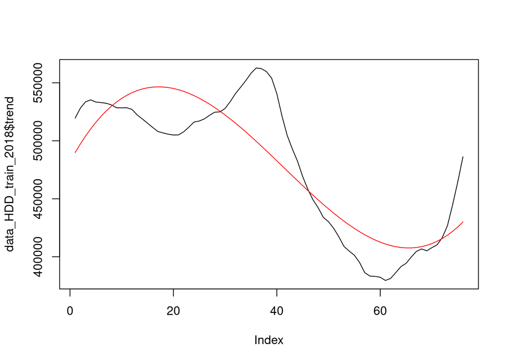

```r
data_HDD_train_2018 <- data_HDD[1:76,]
data_HDD_test_2018 <- data_HDD[77:80,]

hp_2018 <- hpfilter(data_HDD_train_2018$HDD,freq=10,type="frequency", drift=TRUE)
data_HDD_train_2018$trend <- hp_2018$trend
data_HDD_train_2018$t <- c(1:76)
data_HDD_train_2018$t2 <- data_HDD_train_2018$t^2
data_HDD_train_2018$t3 <- data_HDD_train_2018$t^3

model_trend <- lm(trend ~ t + t2 + t3, data_HDD_train_2018)
plot(data_HDD_train_2018$trend, type = "l")
lines(model_trend$fitted.values, col = "red")
```

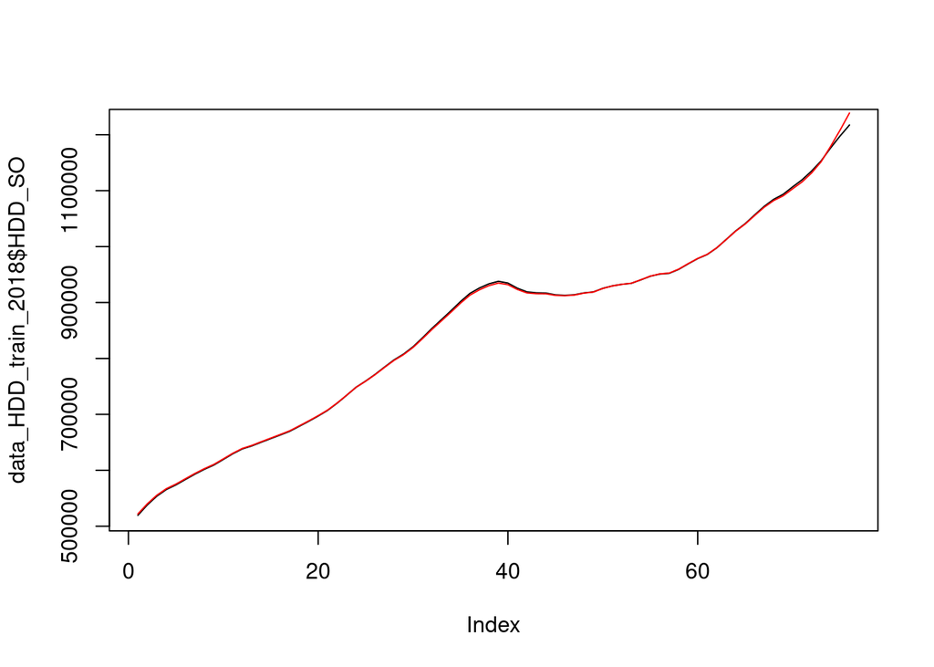

```r
model_hdd <- lm(HDD_SO ~ t + trend, data_HDD_train_2018)
plot(data_HDD_train_2018$HDD_SO, type = "l")
lines(model_hdd$fitted.values, col = "red")
```

```r
t <- as.data.frame(rbind(c(77, 77^2, 77^3), c(78, 78^2, 78^3), c(79, 79^2, 79^3), c(80, 80^2, 80^3)))
colnames(t) <- c("t", "t2", "t3")
predpoved_trend <- predict(model_trend, newdata = cbind(1, t))

hdd_predpoved_data <- as.data.frame(cbind(1, "trend" = predpoved_trend, "t" = c(77:80)))
predpoved_hdd <- predict(model_hdd, newdata = hdd_predpoved_data)
rbind(predpoved_hdd, data_HDD_test_2018$HDD_SO)
```

```
##                     1       2       3       4
## predpoved_hdd 1199192 1214322 1229974 1246161
##               1236075 1259705 1282816 1302173
```

```r
c("MSE" = mean((predpoved_hdd - data_HDD_test_2018$HDD_SO)^2))
```

```
##        MSE
## 2337414924
```

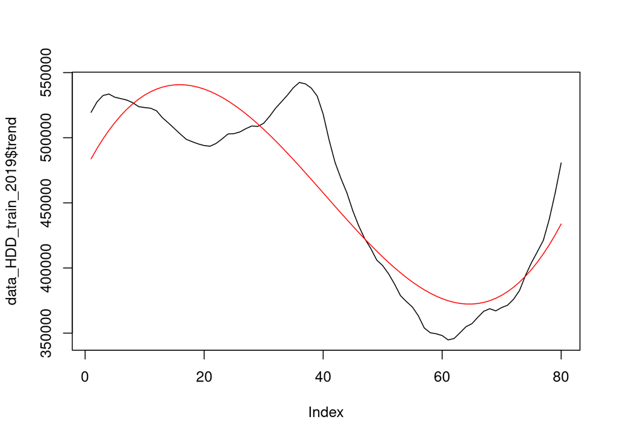

```r
data_HDD_train_2019 <- data_HDD[1:80,]
data_HDD_test_2019 <- data_HDD[81:84,]

hp_2019 <- hpfilter(data_HDD_train_2019$HDD,freq=10,type="frequency", drift=TRUE)
data_HDD_train_2019$trend <- hp_2019$trend
data_HDD_train_2019$t <- c(1:80)
data_HDD_train_2019$t2 <- data_HDD_train_2019$t^2
data_HDD_train_2019$t3 <- data_HDD_train_2019$t^3

model_trend_2019 <- lm(trend ~ t + t2 + t3, data_HDD_train_2019)
plot(data_HDD_train_2019$trend, type = "l")
lines(model_trend_2019$fitted.values, col = "red")
```

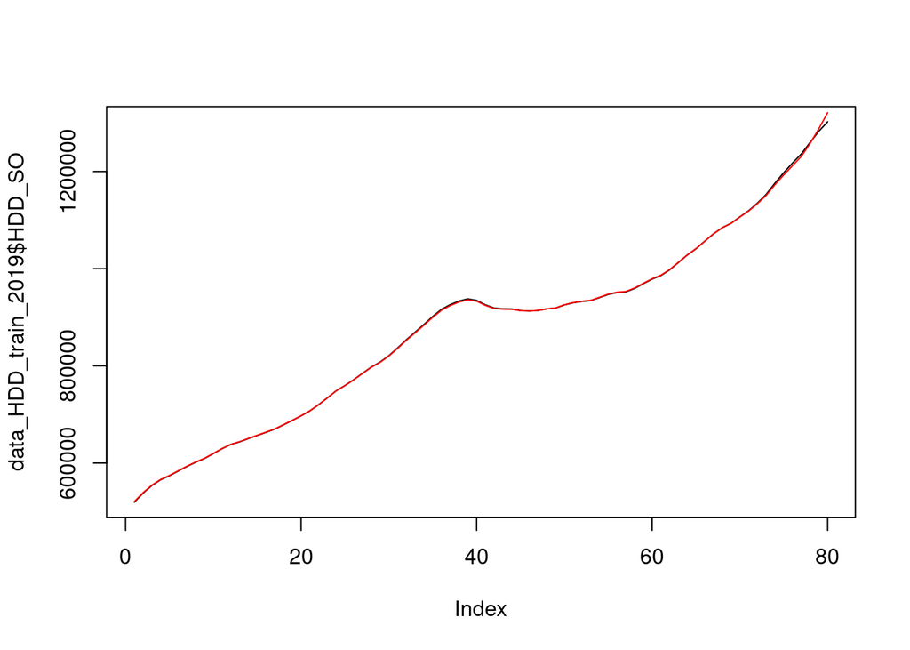

```r
model_hdd_2019 <- lm(HDD_SO ~ t + trend, data_HDD_train_2019)
plot(data_HDD_train_2019$HDD_SO, type = "l")
lines(model_hdd_2019$fitted.values, col = "red")
```

```r
t_2019 <- as.data.frame(rbind(c(81, 81^2, 81^3), c(82, 82^2, 82^3), c(83, 83^2, 83^3), c(84, 84^2, 84^3)))
colnames(t_2019) <- c("t", "t2", "t3")
predpoved_trend_2019 <- predict(model_trend_2019, newdata = cbind(1, t_2019))

hdd_predpoved_data_2019 <- as.data.frame(cbind(1, "trend" = predpoved_trend_2019, "t" = c(81:84)))
predpoved_hdd_2019 <- predict(model_hdd_2019, newdata = hdd_predpoved_data_2019)

rbind(predpoved_hdd_2019, data_HDD_test_2019$HDD_SO)
```

```
##                          1       2       3       4
## predpoved_hdd_2019 1294635 1314756 1335593 1357162
##                    1314631 1322895 1331239 1334061
```

```r
c("R-squared" = cor(predpoved_hdd_2019, data_HDD_test_2019$HDD_SO)^2)
```

```
## R-squared
## 0.9554744
```

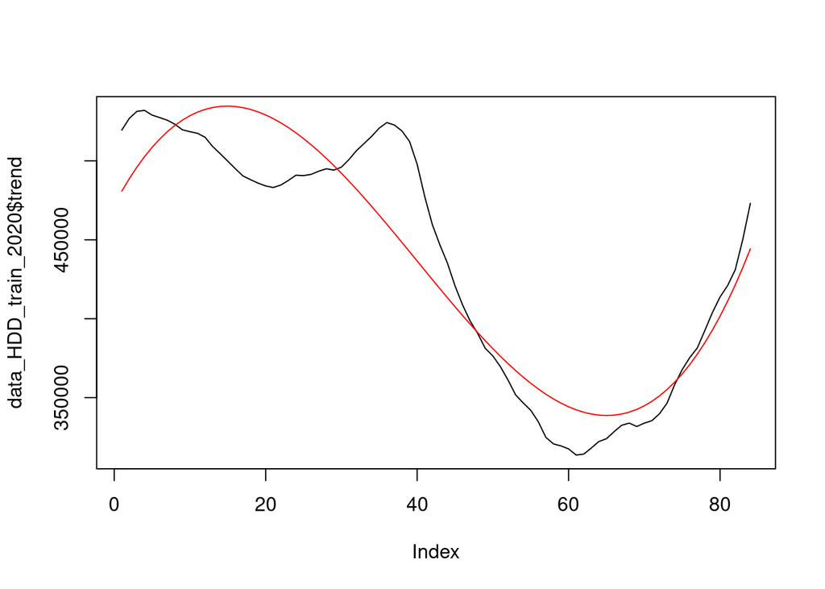

```r
data_HDD_train_2020 <- data_HDD[1:84,]
data_HDD_test_2020 <- data_HDD[85:88,]

hp_2020 <- hpfilter(data_HDD_train_2020$HDD,freq=10,type="frequency", drift=TRUE)
data_HDD_train_2020$trend <- hp_2020$trend
data_HDD_train_2020$t <- c(1:84)
data_HDD_train_2020$t2 <- data_HDD_train_2020$t^2
data_HDD_train_2020$t3 <- data_HDD_train_2020$t^3

model_trend_2020 <- lm(trend ~ t + t2 + t3, data_HDD_train_2020)
plot(data_HDD_train_2020$trend, type = "l")
lines(model_trend_2020$fitted.values, col = "red")
```

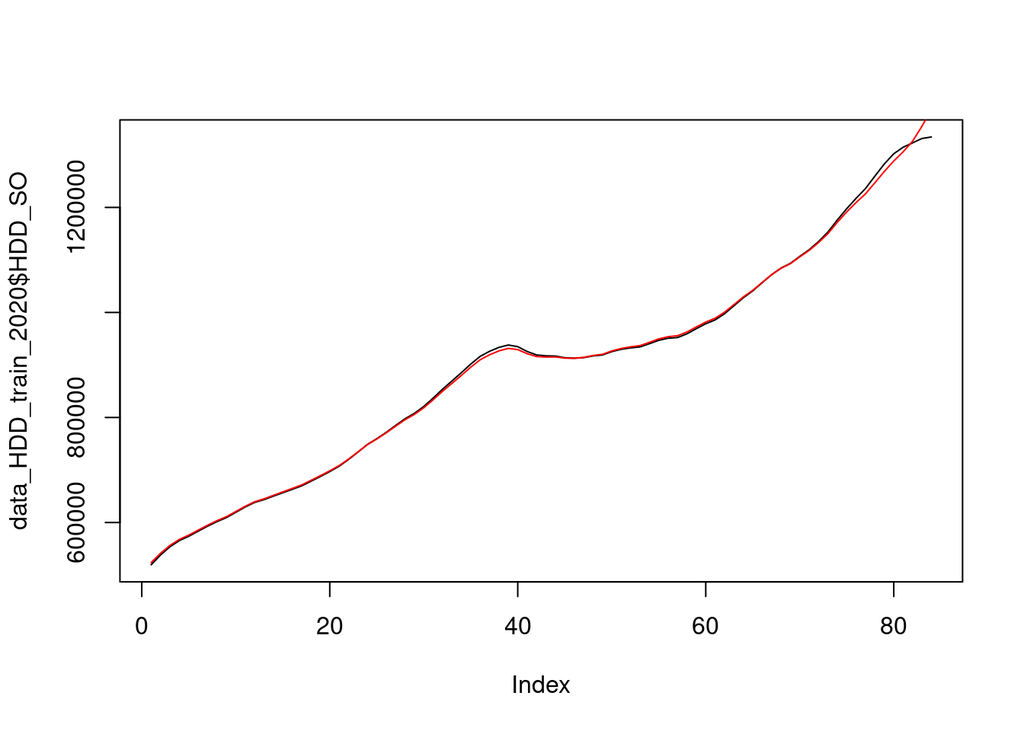

```r
model_hdd_2020 <- lm(HDD_SO ~ t + trend, data_HDD_train_2020)
plot(data_HDD_train_2020$HDD_SO, type = "l")
lines(model_hdd_2020$fitted.values, col = "red")
```

```r
t_2020 <- as.data.frame(rbind(c(85, 85^2, 85^3), c(86, 86^2, 86^3), c(87, 87^2, 87^3), c(88, 88^2, 88^3)))
colnames(t_2020) <- c("t", "t2", "t3")
predpoved_trend_2020 <- predict(model_trend_2020, newdata = cbind(1, t_2020))

hdd_predpoved_data_2020 <- as.data.frame(cbind(1, "trend" = predpoved_trend_2020, "t" = c(85:88)))
predpoved_hdd_2020 <- predict(model_hdd_2020, newdata = hdd_predpoved_data_2020)
rbind(predpoved_hdd_2020, data_HDD_test_2020$HDD_SO)
```

```
##                          1       2       3       4
## predpoved_hdd_2020 1382539 1405867 1429987 1454915
##                    1333182 1344134 1374968 1415621
```

```r
c("R-squared" = cor(predpoved_hdd_2020, data_HDD_test_2020$HDD_SO)^2)
```

```
## R-squared
## 0.9513827
```

## Úkol 3.3

Sestrojte model pro předpověď počtu živě narozených dětí v ČR. Model by měl být schopen předpovídat počet živě narozených dětí na 5 let dopředu – důvodem pro předpověď je potřeba plánování kapacity školek a možnost včasné reakce na jejich případný nedostatek/nadbytek. Hlavní důraz v tomto úkolu je kladen na detailní popis základní logiky a struktury modelu plus hlavní konceptuální kroky při získávání předpovědi.

```r
data_ <- read.csv("Data_ML_narozeni.csv", sep = ";")
colnames(data_) <- data_[1,]

data_narozeni <- tibble(
  Vek_matky = as.numeric(data_$Prum_vek_matky[2:31]),
  Rozvodovost = as.numeric(data_$Rozvodovost[2:31]),
  HDP = as.numeric(data_$HDP[2:31]),
  Nezamestnanost = as.numeric(data_$Nezamestnanost[2:31]),
  Plodnost = as.numeric(data_$Uhrnna_plodnost[2:31]),
  Pocet_narozenych = as.numeric(data_$Zive_narozeni[2:31])
)
data_narozeni$ZmenaHDP <- 1

for(i in 2:30){
  data_narozeni[i,7] <- data_narozeni$HDP[i]/data_narozeni$HDP[(i-1)]
}

#Vytvoření modelu
model_narozeni <- lm(Pocet_narozenych ~ Vek_matky + Rozvodovost + ZmenaHDP + Nezamestnanost + Plodnost, data = data_narozeni)
coef(model_narozeni)
```

```
##    (Intercept)      Vek_matky    Rozvodovost       ZmenaHDP Nezamestnanost
##     74869.8588     -2843.8137       981.5082    -26275.7040      1317.5153
##       Plodnost
##     62119.4428
```

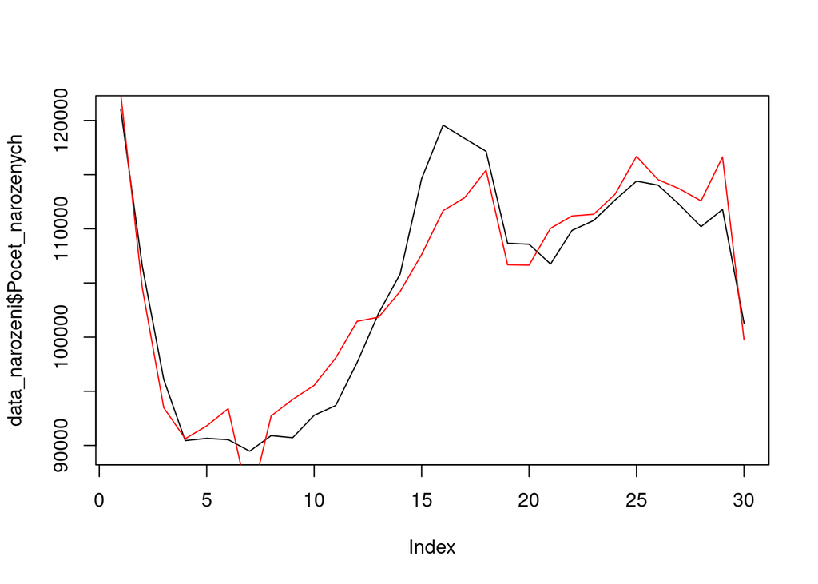

```r
plot(data_narozeni$Pocet_narozenych, type = "l")
lines(model_narozeni$fitted.values, col = "red")
```

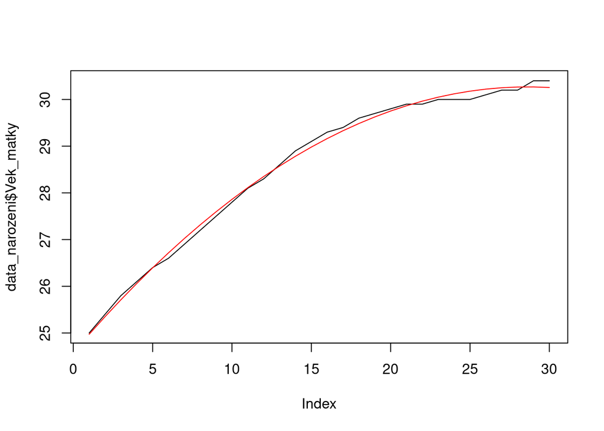

```r
data_narozeni$t <- c(1:30)
data_narozeni$t2 <- (data_narozeni$t)^2


#Modelování předpovědi věku matky
model_vekMatky <- lm(Vek_matky ~ t + t2, data_narozeni)
predpoved_vekMatky <- c()
for(i in 31:35){
  predpoved_vekMatky[(i-30)] <- sum(model_vekMatky$coefficients * c(1, i, i^2))
}

plot(data_narozeni$Vek_matky, type = "l")
lines(model_vekMatky$fitted.values, col = "red")
```

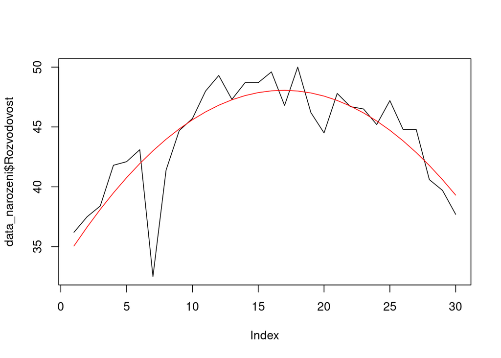

```r
#Modelování předpovědi Rozvodovosti
model_Rozvodovost <- lm(Rozvodovost ~ t + t2, data_narozeni)
predpoved_Rozvodovost <- c()
for(i in 31:35){
  predpoved_Rozvodovost[(i-30)] <- sum(model_Rozvodovost$coefficients * c(1, i, i^2))
}

plot(data_narozeni$Rozvodovost, type = "l")
lines(model_Rozvodovost$fitted.values, col = "red")
```

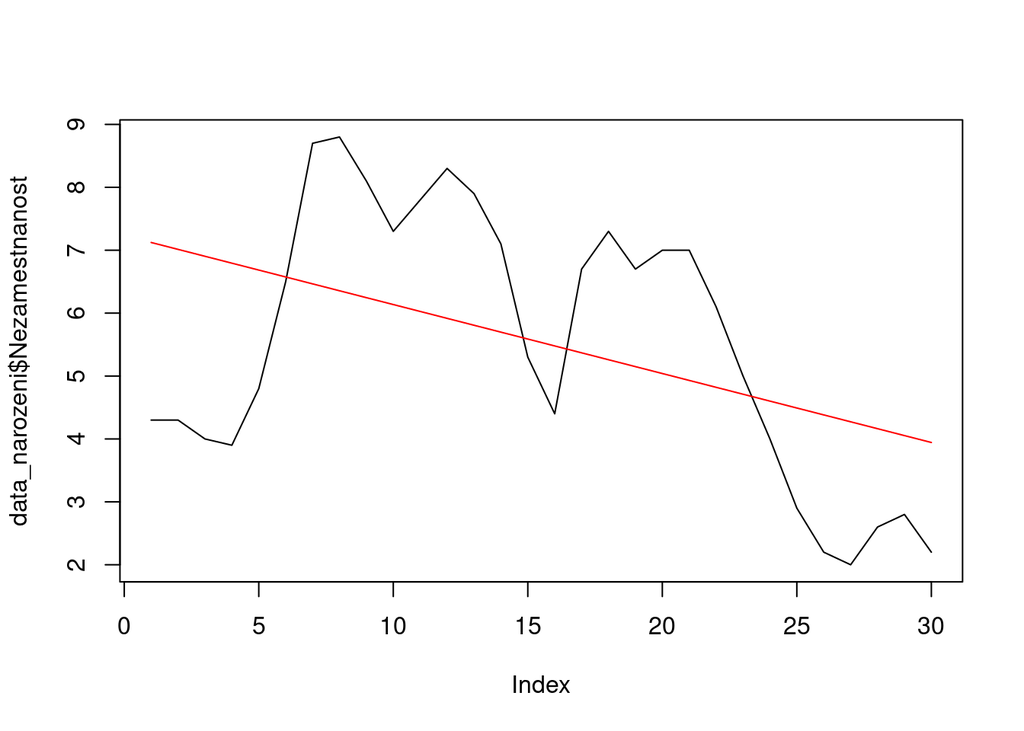

```r
hp_Rozvodovost <- hpfilter(data_narozeni$Rozvodovost,freq=10,type="frequency", drift=TRUE)
data_narozeni$HP_Rozvodovost <- hp_Rozvodovost$trend

#Modelování předpovědi HDP -> předpokládáme, že steady-state je růst o průměr
predpoved_zmenaHDP <- rep(mean(data_narozeni$ZmenaHDP), 5)
predpoved_zmenaHDP2 <- rep(2, 5) #steady-state podle předpovědi

#Modelování předpovědi nezaměstnanosti
model_nezamestnanost <- lm(Nezamestnanost ~ t, data_narozeni)
predpoved_Nezamestnanost <- c()
for(i in 31:35){
  predpoved_Nezamestnanost[(i-30)] <- sum(model_nezamestnanost$coefficients * c(1, i))
}

plot(data_narozeni$Nezamestnanost, type = "l")
lines(model_nezamestnanost$fitted.values, col = "red")
```

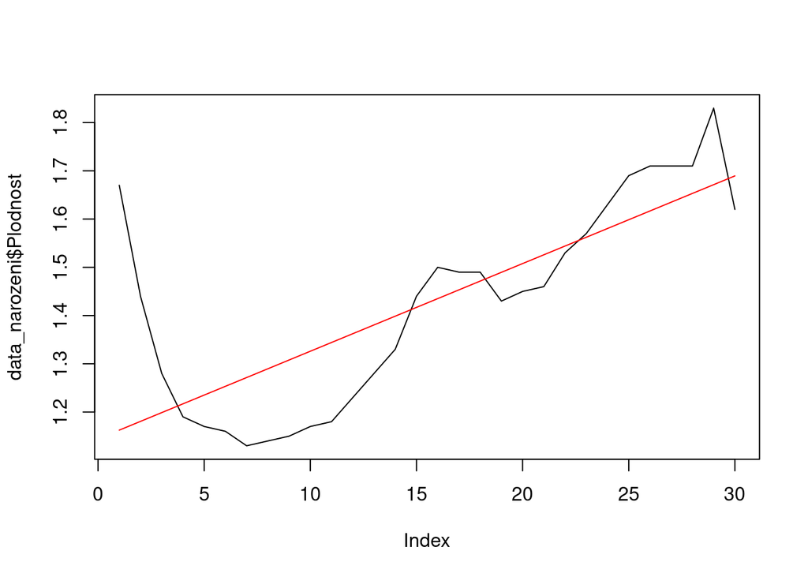

```r
#Modelování předpovědi plodnosti
model_Plodnost <- lm(Plodnost ~ t, data_narozeni)
plot(data_narozeni$Plodnost, type = "l")
lines(model_Plodnost$fitted.values, col = "red")
```

```r
predpoved_Plodnost <- c()
for(i in 31:35){
  predpoved_Plodnost[(i-30)] <- sum(model_Plodnost$coefficients * c(1, i))
}

predpoved <- as.data.frame(cbind("Vek_matky" = predpoved_vekMatky, "Rozvodovost" = predpoved_Rozvodovost, "ZmenaHDP" = predpoved_zmenaHDP, "Nezamestnanost" = predpoved_Nezamestnanost, "Plodnost" = predpoved_Plodnost))
predpoved2 <- as.data.frame(cbind("Vek_matky" = predpoved_vekMatky, "Rozvodovost" = predpoved_Rozvodovost, "ZmenaHDP" = predpoved_zmenaHDP2, "Nezamestnanost" = predpoved_Nezamestnanost, "Plodnost" = predpoved_Plodnost))
```

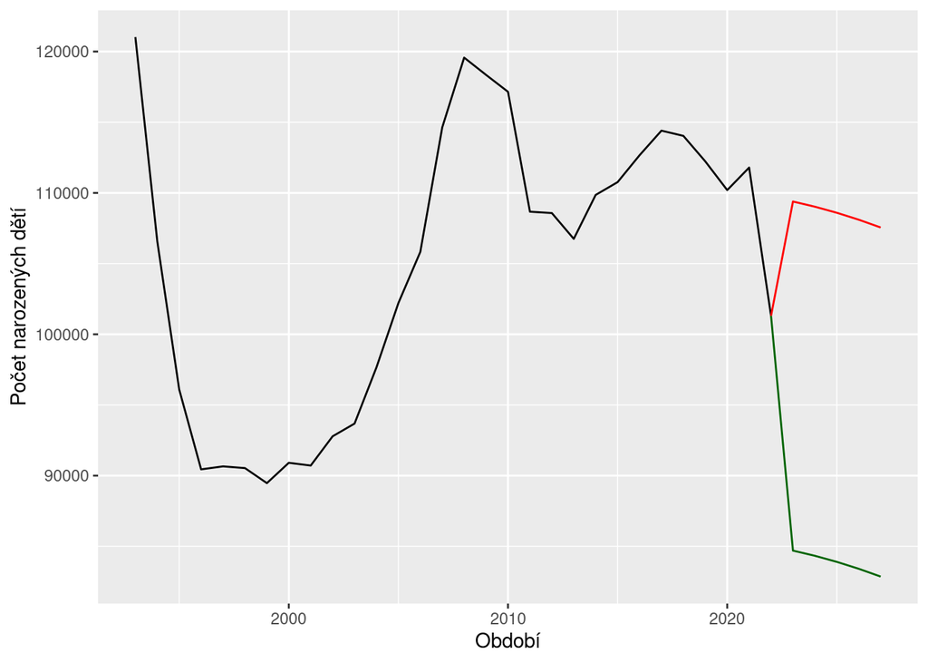

```r
predikce_poctuDeti <- as.data.frame(matrix(nrow = 6, ncol = 0))
predikce_poctuDeti$Roky <- c(2022:2027)
predikce_poctuDeti$Pocet <- c(data_narozeni$Pocet_narozenych[30],predict(model_narozeni, newdata = predpoved))

predikce_poctuDeti2 <- as.data.frame(matrix(nrow = 6, ncol = 0))
predikce_poctuDeti2$Roky <- c(2022:2027)
predikce_poctuDeti2$Pocet <- c(data_narozeni$Pocet_narozenych[30],predict(model_narozeni, newdata = predpoved2))

ggplot() +
  geom_line(data = data_narozeni, aes(x = c(1993:2022), y = Pocet_narozenych)) +
  geom_line(data = predikce_poctuDeti, aes(x = Roky, y = Pocet), color = "red") +
  geom_line(data = predikce_poctuDeti2, aes(x = Roky, y = Pocet), color = "darkgreen") +
  xlab("Období") + ylab("Počet narozených dětí")
```